# Impact Analysis of Severe Weather Events on Population and Economic Health in the United States: Wind- and Rain-related Most Damaging from 1950-2011

**NOTE: I am submitting this early, but seeing how this is a public repository, anyone can see it right away. If you need help, you can use this as a guide to understanding the problem, but please do not just copy/paste this code. R has a steep learning curve, but you will get it with time and experience, I have faith in you.**

## 1. Synopsis

“Storms and other severe weather events can cause both public health and economic problems for communities and municipalities. Many severe events can result in fatalities, injuries, and property damage, and preventing such outcomes to the extent possible is a key concern.”

## 2. Data Processing

A GitHub repository was created for this document at: https://github.com/atet/coursera/tree/master/RepData_PeerAssessment2

### 2.A Loading Data

The original required data file archive `repdata-data-StormData.csv.bz2` is downloaded from the course website and uncompressed locally:

```r
setwd("~/")
filepath_source      <- "https://d396qusza40orc.cloudfront.net/repdata%2Fdata%2FStormData.csv.bz2"
filepath_destination <- "~/repdata-data-StormData.csv.bz2"
download.file(url = filepath_source, destfile = filepath_destination, method = "curl")
data                 <- bzfile(description = filepath_destination)
# This may take a while!!!
data                 <- read.csv(data, stringsAsFactors = FALSE) # Remember to set stringsAsFactors = FALSE
# Saving out as compressed R object (*.rds) for convenience (in case the file needs to be loaded again, will take R less time)
saveRDS(data, "~/repdata-data-StormData.rds")
```

Reload the dataset from the R object compressed form:

```r
data <- readRDS("~/repdata-data-StormData.rds")
```

This large dataset initially contains 902,297 observations with 37 variables each as seen below:

```
## 'data.frame':    902297 obs. of  37 variables:
##  $ STATE__   : num  1 1 1 1 1 1 1 1 1 1 ...
##  $ BGN_DATE  : chr  "4/18/1950 0:00:00" "4/18/1950 0:00:00" "2/20/1951 0:00:00" "6/8/1951 0:00:00" ...
##  $ BGN_TIME  : chr  "0130" "0145" "1600" "0900" ...
##  $ TIME_ZONE : chr  "CST" "CST" "CST" "CST" ...
##  $ COUNTY    : num  97 3 57 89 43 77 9 123 125 57 ...
##  $ COUNTYNAME: chr  "MOBILE" "BALDWIN" "FAYETTE" "MADISON" ...
##  $ STATE     : chr  "AL" "AL" "AL" "AL" ...
##  $ EVTYPE    : chr  "TORNADO" "TORNADO" "TORNADO" "TORNADO" ...
##  $ BGN_RANGE : num  0 0 0 0 0 0 0 0 0 0 ...
##  $ BGN_AZI   : chr  "" "" "" "" ...
##  $ BGN_LOCATI: chr  "" "" "" "" ...
##  $ END_DATE  : chr  "" "" "" "" ...
##  $ END_TIME  : chr  "" "" "" "" ...
##  $ COUNTY_END: num  0 0 0 0 0 0 0 0 0 0 ...
```

[output cut: 23 more lines]

Supplementary data: Census data of U.S. population by county from 1900-1990 from the National Bureau of Economic Research (http://www.nber.org/census/pop/cencounts.csv):

```r
# Download file from source to local
download.file(url = "http://www.nber.org/census/pop/cencounts.csv", destfile = "~/cencounts.csv")
```

```r
# Load the downloaded file
us_population <- read.csv(file = "~/cencounts.csv", stringsAsFactors = FALSE)
```

### 2.B Cleaning Data

**2.B.i Date and time**

```r
time_zones <- data.frame(
  "Abbreviation" = c(
    "SCT","GST","UTC","AST","ADT","EST","EDT",
    "CST","CDT","MST","MDT","PST","PDT","HST","SST"),
  "Description" = c(
    "Seychelles Time","Gulf Standard Time","Universal Time Coordinated",
    "Altantic Standard Time","Altantic Daylight Time","Eastern Standard Time",
    "Eastern Daylight Time","Central Standard Time","Central Daylight Time",
    "Mountain Standard Time","Mountain Daylight Time","Pacific Standard Time",
    "Pacific Daylight Time","Hawaii-Aleutian Standard Time","Samoa Standard Time"),
  "UTC Offset" = c(
    "0400","0400","0000","-0400","-0300","-0500","-0400",
    "-0600","-0500","-0700","-0600","-0800","-0700","-1000",
    "-1100")
  )
knitr::kable(time_zones)
```

| Abbreviation | Description | UTC.Offset |
| --- | --- | --- |
| SCT | Seychelles Time | 0400 |
| GST | Gulf Standard Time | 0400 |
| UTC | Universal Time Coordinated | 0000 |
| AST | Altantic Standard Time | -0400 |
| ADT | Altantic Daylight Time | -0300 |
| EST | Eastern Standard Time | -0500 |
| EDT | Eastern Daylight Time | -0400 |
| CST | Central Standard Time | -0600 |
| CDT | Central Daylight Time | -0500 |
| MST | Mountain Standard Time | -0700 |
| MDT | Mountain Daylight Time | -0600 |
| PST | Pacific Standard Time | -0800 |
| PDT | Pacific Daylight Time | -0700 |
| HST | Hawaii-Aleutian Standard Time | -1000 |
| SST | Samoa Standard Time | -1100 |

Create a uniform date/time value in UTC (Universal Time, Coordinated) of `POSIX` type using the `$BGN_DATE` and `$BGN_TIME`:

```r
# Trim $BGN_DATE since the date is correct, but the trailing time are all irrelevant "0:00:00""
data$date <- gsub(" 0:00:00", "", data$BGN_DATE)
# Clean up timezone $TIME_ZONE, some values need to be changed for consistency
data$TIME_ZONE[data$TIME_ZONE == "CSt"] = "CST" # Typo
data$TIME_ZONE[data$TIME_ZONE == "CSC"] = "CST" # Typo
data$TIME_ZONE[data$TIME_ZONE == "ESt"] = "EST" # Typo
data$TIME_ZONE[data$TIME_ZONE == "ESY"] = "EST" # Typo
data$TIME_ZONE[data$TIME_ZONE == "GMT"] = "UTC" # Change GMT to UTC
data$TIME_ZONE[data$TIME_ZONE == "AKS"] = "HST" # Change AKS to HST
# Nine entries have unknown "UNK" timezones, The appropriate timezone was determined based on their $COUNTYNAME and $STATE
print(data[data$TIME_ZONE == "UNK", c("date", "COUNTYNAME", "STATE", "TIME_ZONE")])
```

```
##             date COUNTYNAME STATE TIME_ZONE
## 23087  3/31/1973     OCONEE    GA       UNK
## 27702  3/20/1980     HAWAII    HI       UNK
## 30669  8/13/1974      COLES    IL       UNK
## 35244  4/21/1967       RUSH    IN       UNK
## 67899   6/1/1956    HAMPDEN    MA       UNK
## 120704  4/2/1957       LOVE    OK       UNK
## 143198  6/4/1980    PERKINS    SD       UNK
## 154637 5/13/1972   MCLENNAN    TX       UNK
## 160236 5/11/1982  ARMSTRONG    TX       UNK
```

```r
# Detrmined the correct time zones and manually added
data[data$TIME_ZONE == "UNK" & data$COUNTYNAME == "OCONEE",]$TIME_ZONE = "EDT"
data[data$TIME_ZONE == "UNK" & data$COUNTYNAME == "HAWAII",]$TIME_ZONE = "HST"
data[data$TIME_ZONE == "UNK" & data$COUNTYNAME == "COLES",]$TIME_ZONE = "CDT"
data[data$TIME_ZONE == "UNK" & data$COUNTYNAME == "RUSH",]$TIME_ZONE = "EDT"
data[data$TIME_ZONE == "UNK" & data$COUNTYNAME == "HAMPDEN",]$TIME_ZONE = "EDT"
data[data$TIME_ZONE == "UNK" & data$COUNTYNAME == "LOVE",]$TIME_ZONE = "CDT"
data[data$TIME_ZONE == "UNK" & data$COUNTYNAME == "PERKINS",]$TIME_ZONE = "MDT"
data[data$TIME_ZONE == "UNK" & data$COUNTYNAME == "MCLENNAN",]$TIME_ZONE = "CDT"
data[data$TIME_ZONE == "UNK" & data$COUNTYNAME == "ARMSTRONG",]$TIME_ZONE = "CDT"
# Merge data with UTC signed offset time from data frame time_zones
data <- merge(
  x = data, y = time_zones[,c(1,3)],
  by.x = "TIME_ZONE", by.y = "Abbreviation")
# Combine date, time, and UTC offset into a charater vector
data$datetime <- paste(data$date, data$BGN_TIME, data$UTC.Offset, sep = " ")
# Since $BGN_TIME is given in 12-hour and 24-hour format, convert everything to 24-hour format in new column $time_24
time_24h                  <- strptime(data$datetime, format="%m/%d/%Y %H%M %z")     # E.g. "8/18/1994 2322 -0300"
time_12h                  <- strptime(data$datetime, format="%m/%d/%Y %H:%M:%S %p %z") # E.g. "8/28/2001 12:00:00 PM -1100"
time_24h[is.na(time_24h)] <- time_12h[!is.na(time_12h)] # Will produce warning, can ignore
# Make new column time_utc
data$time_utc             <- time_24h
# NOTE: Though there are various additional issues with date and time, there will be no more subsequent cleaning here.
```

**2.B.ii Necessary variables**

Subset the source data into only columns that relate to weather event, injury/loss-of-life, and economic impact.

Including the date of the event cleaned up previously as `$time_utc`, using the documentation provided by the National Weather Service (https://d396qusza40orc.cloudfront.net/repdata%2Fpeer2_doc%2Fpd01016005curr.pdf), the following variables relate to weather event, injury/loss-of-life, or economic impact.

```r
variables <- data.frame(
  "Variable" = c(
    "time_utc", "EVTYPE","INJURIES","FATALITIES","PROPDMG",
    "PROPDMGEXP","CROPDMG","CROPDMGEXP"),
  "Description" = c(
    "Beginning date and time of event (UTC).", "Type of event.", "Reported injuries from event",
    "Reported deaths from event.", "Damage to property", "Property damage exponent.",
    "Damage to agricultural crops.", "Crop damage exponent.")
  )
knitr::kable(variables)
```

| Variable | Description |
| --- | --- |
| time_utc | Beginning date and time of event (UTC). |
| EVTYPE | Type of event. |
| INJURIES | Reported injuries from event |
| FATALITIES | Reported deaths from event. |
| PROPDMG | Damage to property |
| PROPDMGEXP | Property damage exponent. |
| CROPDMG | Damage to agricultural crops. |
| CROPDMGEXP | Crop damage exponent. |

Subset the main data into the eight variables appropriate for this analysis.

```r
data <- data[ , colnames(data) %in% variables$Variable]
```

**2.B.iii Monetary values**

To determine a single monetary value for property and crop damage, `$PROPDMG`, `$PROPDMGEXP`, `$CROPDMG`, and `$CROPDMGEXP` must be deciphered and combined.

The following information is described in Section 2.7 from https://d396qusza40orc.cloudfront.net/repdata%2Fpeer2_doc%2Fpd01016005curr.pdf.

The `$PROPDMG` and `$CROPDMG` values are all numerical, the corresponding `$*EXP` columns are 10^exponent multipliers for these values and the value is in U.S dollars.

Together, `$PROPDMGEXP` and `$CROPDMGEX` have 20 unique symbols as multipliers, these need to be harmonized:

```
##  [1] ""  "K" "M" "B" "+" "0" "m" "5" "6" "?" "1" "3" "4" "2" "7" "H" "8"
## [18] "h" "-" "k"
```

Harmonize the different exponent symbols:

```r
# Symbols that are missing (NA), blank (""), "+", "-", or "?" will be replaced with a zero (10^0 = 1)
data$PROPDMGEXP[is.na(data$PROPDMGEXP) | data$PROPDMGEXP == "" |
  data$PROPDMGEXP == "?" | data$PROPDMGEXP == "+" | data$PROPDMGEXP == "-"] <- 0
data$CROPDMGEXP[is.na(data$CROPDMGEXP) | data$CROPDMGEXP == "" |
  data$CROPDMGEXP == "?" | data$CROPDMGEXP == "+" | data$CROPDMGEXP == "-"] <- 0
# Symbols "h" or "H" will be replaced with 2 (H = hundred = 10^2 = 100)
data$PROPDMGEXP[data$PROPDMGEXP == "h" | data$PROPDMGEXP == "H"] <- 2
data$CROPDMGEXP[data$CROPDMGEXP == "h" | data$CROPDMGEXP == "H"] <- 2
# Symbols "k" or "K" will be replaced with 3 (K = kilo = thousand = 10^3 = 1000)
data$PROPDMGEXP[data$PROPDMGEXP == "k" | data$PROPDMGEXP == "K"] <- 3
data$CROPDMGEXP[data$CROPDMGEXP == "k" | data$CROPDMGEXP == "K"] <- 3
# Symbols "m" or "M" will be replaced with 6 (M = mega = million = 10^6 = 1000000)
data$PROPDMGEXP[data$PROPDMGEXP == "m" | data$PROPDMGEXP == "M"] <- 6
data$CROPDMGEXP[data$CROPDMGEXP == "m" | data$CROPDMGEXP == "M"] <- 6
# Symbols "m" or "M" will be replaced with 9 (B = billion = 10^9 = 1000000000)
data$PROPDMGEXP[data$PROPDMGEXP == "b" | data$PROPDMGEXP == "B"] <- 9
data$CROPDMGEXP[data$CROPDMGEXP == "b" | data$CROPDMGEXP == "B"] <- 9
# The remaining symbols are already numberic and assumed correct exponents
# Make column $total_crop_damage
data$total_crop_damage <- data$CROPDMG * (10 ^ as.numeric(data$CROPDMGEXP))
# Make column $total_property_damage
data$total_property_damage <- data$PROPDMG * (10 ^ as.numeric(data$PROPDMGEXP))
# Make column $total_damage that combines the total property and crop damage
data$total_damage <- data$total_crop_damage + data$total_property_damage
```

**2.B.iv Event type**

The recorded event types are different between years (source: http://www.ncdc.noaa.gov/stormevents/details.jsp?type=eventtype): * 1950-1955: Tornadoes * 1955-1996: Tornadoes, thunderstorm winds, and hail * 1996-present: 48 different event types

Initially, there are 985 different unique `$EVTYPE` which describe the weather event.

Clearly there are differences between labels and typos present, therefore these labels need to be harmonized.

I will only consider the following types of events (with priority): 1. Cold-related (e.g. “GROUND BLIZZARD”, “ICE STORM”, “RECORD SNOWFALL”, etc.) 2. Heat-related (e.g. “EXCESSIVE HEAT”, “WILD/FOREST FIRE”) 3. Coastal (e.g. “Heavy surf and wind”, “Beach Erosion”, “TSUNAMI”, etc.) 4. Wind-only (e.g. “High winds”, “GUSTNADO”, “TORNADO”, etc.) 5. Rain-only (e.g. “Mudslides”, “RAPIDLY RISING WATER”, “Wet Year”, etc.) 6. Other, entries with `$EVTYPE` labels that are incomplete or “?”, “Summary of…”, “”No Severe Weather“”, etc.

```r
# Replace original terms with one of the five terms using regular expressions and list of related words
# Cold-related events
data$EVTYPE[
  grepl(
    "cold|cool|snow|ice|frost|freez|icy|chill|blizzard|wint|low|glaze|fog|avalanche|avalance|hypothermia",
    data$EVTYPE, ignore.case = TRUE)
  ] <- "cold"
# Heat-related events
data$EVTYPE[
  grepl(
    "heat|high|fire|hot|warm|drought|dry|driest",
    data$EVTYPE, ignore.case = TRUE)
  ] <- "heat"
# Coastal events
data$EVTYPE[
  grepl(
    "coastal|seas|slump|beach|tsunami|current|marine|tidal|tide|hurricane|surf|typhoon|swell|spout|seiche|tropical|cstl|wave",
    data$EVTYPE, ignore.case = TRUE)
  ] <- "coastal"
# Wind-only events
data$EVTYPE[
  grepl(
    "wind|wnd|gust|dust|smoke|ash|funnel|cloud|burst|tornado|torndao|volcanic",
    data$EVTYPE, ignore.case = TRUE)
  ] <- "wind"
# Rain-only events
data$EVTYPE[
  grepl(
    "rain|flood|fldg|storm|slide|hail|sleet|precip|stream|wet|light|lignt|cloud|tstm|fog|vog|water|shower|mix",
    data$EVTYPE, ignore.case = TRUE)
  ] <- "rain"
# "Other" events
data$EVTYPE[
  !grepl(
    "cold|heat|coastal|wind|rain",
    data$EVTYPE, ignore.case = TRUE)
  ] <- "other"
# Resulting distribution of events by these six different event categories
print(table(data$EVTYPE))
```

```
##
## coastal    cold    heat   other    rain    wind
##   19393   49364   33039     208  347186  453107
```

**For the purposes of this study, I will now consider the `data` to be harmonized, clean, and ready for analysis**.

```
## 'data.frame':    902297 obs. of  11 variables:
##  $ EVTYPE               : chr  "heat" "heat" "heat" "rain" ...
##  $ FATALITIES           : num  0 0 0 0 0 0 0 0 0 0 ...
##  $ INJURIES             : num  0 0 0 0 0 0 0 0 0 0 ...
##  $ PROPDMG              : num  0 0 0 0 0 0 0 0 0 0 ...
##  $ PROPDMGEXP           : chr  "0" "0" "0" "0" ...
##  $ CROPDMG              : num  0 0 0 0 0 0 0 0 0 0 ...
##  $ CROPDMGEXP           : chr  "0" "0" "0" "0" ...
##  $ time_utc             : POSIXlt, format: "1994-10-01 09:00:00" "1993-09-05 18:00:00" ...
##  $ total_crop_damage    : num  0 0 0 0 0 0 0 0 0 0 ...
##  $ total_property_damage: num  0 0 0 0 0 0 0 0 0 0 ...
##  $ total_damage         : num  0 0 0 0 0 0 0 0 0 0 ...
## NULL
```

**2.B.v Supplementary data**

Clean up population data: Subset needed rows and columns.

```r
# For this analysis, only considering total U.S. population in row 1 and year 1950-1990 in columns 6:10
us_population <- us_population[1,c(6:10)]
```

## 3. Results

**NOTE: Histogram image is not directly embedded since if this document is viewed as an .md file through GitHub, it will not display, therefore I am sourcing the image through Markdown instead.**

### 3.A Population Health Impact Resulting From Weather Events

The number of injuries and fatalities are plotted across event types in Figure 1.

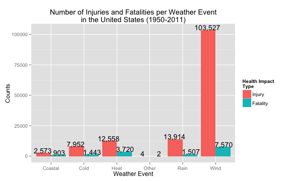

```r
# Gather information determining the relationship between event type with injuries and fatalities
health_by_event <- rbind(
  data.frame(
    event = c("Coastal","Cold","Heat","Other","Rain","Wind"),
    count = tapply(X = data$INJURIES, INDEX = data$EVTYPE, FUN = sum),
    type = "Injury"),
  data.frame(
    event = c("Coastal","Cold","Heat","Other","Rain","Wind"),
    count = tapply(X = data$FATALITIES, INDEX = data$EVTYPE, FUN = sum),
    type = "Fatality"))

# Plot injuries/fatalities by event type
library(ggplot2)
ggplot(health_by_event, aes(x = event, y = count, fill = type)) +
  geom_bar(position = "dodge", stat = "identity") +
  labs(x = "Weather Event", y = "Counts",
    title = "Number of Injuries and Fatalities per Weather Event\nin the United States (1950-2011)") +
  scale_fill_discrete(name = "Health Impact\nType") +
  geom_text(aes(
    label = formatC(round(count, digits = 1), format = "d", big.mark = ",", small.mark = ".", width = 2), ymax = 0),
    size = 5, position = position_dodge(width = 1), vjust = 0)
```

**Figure 1**. Number of injuries and fatalities for a given event type. Injuries and fatalities are summed from each individual event of a given event type.

### 3.B Population Health Impact Resulting From Weather Events Compared to Total U.S. Population Across Decades From 1950-1990

The number of injuries and fatalities are plotted across event types by decade in Figure 2. Additionally, information regarding total U.S. population for each decade is used to normalize. Since the census data was limited to 1900-1990 and the event data only contained `wind` or `rain` catergorized events from 1950s-1990’s, **therefore I will only look into dates from 1950-1999 and these two event types**.

```r
# Additionally, add supplementary information concerning U.S. population counts during the decade of the event
# Subset to just wind and rain event types
data_by_decade        <- data[data$EVTYPE == "rain" | data$EVTYPE == "wind",]
# Make column for decade
data_by_decade$decade <- floor(as.numeric(format(x = data_by_decade$time_utc, format = "%y")) / 10)
# Subset data with relevant decade range from census data, 1950-1999
data_by_decade        <- data_by_decade[data_by_decade$decade >= 5 & data_by_decade$decade <= 9,]
# Using census data by decade, determine percentage of total U.S. population injured of killed.
# Since the total U.S. population is far greater than the number of injuries/fatalities, will consider
# using the full population value (may/may not already account for the deaths from these event)
data_by_decade$decade_population <- NA
data_by_decade[data_by_decade$decade == 5,]$decade_population <- us_population[[1]] # 1950's
data_by_decade[data_by_decade$decade == 6,]$decade_population <- us_population[[2]] # 1960's
data_by_decade[data_by_decade$decade == 7,]$decade_population <- us_population[[3]] # 1970's
data_by_decade[data_by_decade$decade == 8,]$decade_population <- us_population[[4]] # 1980's
data_by_decade[data_by_decade$decade == 9,]$decade_population <- us_population[[5]] # 1990's
data_by_decade$decade_population <- as.numeric(data_by_decade$decade_population)
# Determine percentage of population (of that decade) injured or killed per event.
data_by_decade$injuries_pop_percent   <- (data_by_decade$INJURIES / data_by_decade$decade_population) * 100
data_by_decade$fatalities_pop_percent <- (data_by_decade$FATALITIES / data_by_decade$decade_population) * 100

# Determine total injuries and fatalities percentages for each decade
data_by_decade   <- data_by_decade[order(data_by_decade$decade),]
health_by_decade <- rbind(
  data.frame(
    decade = c("1950's","1960's","1970's","1980's","1990's"),
    count = tapply(X = data_by_decade$injuries_pop_percent, INDEX = list(data_by_decade$decade, data_by_decade$EVTYPE), FUN = sum),
    type = "Injury"),
  data.frame(
    decade = c("1950's","1960's","1970's","1980's","1990's"),
    count = tapply(X = data_by_decade$fatalities_pop_percent, INDEX = list(data_by_decade$decade, data_by_decade$EVTYPE), FUN = sum),
    type = "Fatality"))

# Melt health_by_decade from wide to long
library(reshape2)
health_by_decade_long <- melt(health_by_decade, id.vars=c("decade","type"))
# Make new variable for plot to fill by (combines $type and $variable)
health_by_decade_long$type_var <- paste(health_by_decade_long$type, health_by_decade_long$variable, sep = "_")
# Make $type_var and ordered factor for grouping them by type in plot
health_by_decade_long <- health_by_decade_long
health_by_decade_long$type_var <- factor(health_by_decade_long$type_var, levels = c("Injury_count.rain", "Fatality_count.rain", "Injury_count.wind", "Fatality_count.wind"), ordered = TRUE)

str(health_by_decade_long)
```

```
## 'data.frame':    20 obs. of  5 variables:
##  $ decade  : Factor w/ 5 levels "1950's","1960's",..: 1 2 3 4 5 1 2 3 4 5 ...
##  $ type    : Factor w/ 2 levels "Injury","Fatality": 1 1 1 1 1 2 2 2 2 2 ...
##  $ variable: Factor w/ 2 levels "count.rain","count.wind": 1 1 1 1 1 1 1 1 1 1 ...
##  $ value   : num  0 0 0 0.000098 0.003086 ...
##  $ type_var: Ord.factor w/ 4 levels "Injury_count.rain"<..: 1 1 1 1 1 2 2 2 2 2 ...
```

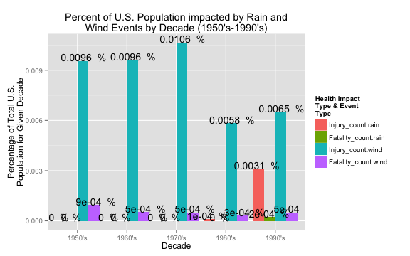

```r
# Plot percent of U.S. population injured/killed from rain or wind events by decade
library(ggplot2)
ggplot(health_by_decade_long, aes(x = decade, y = value, fill = type_var)) +
  geom_bar(position = "dodge", stat = "identity") +
  labs(x = "Decade", y = "Percentage of Total U.S.\nPopulation for Given Decade",
    title = "Percent of U.S. Population impacted by Rain and\nWind Events by Decade (1950's-1990's)") +
  scale_fill_discrete(name = "Health Impact\nType & Event\nType") +
  geom_text(aes(
    label = paste(round(value, digits = 4), " %"), ymax = 0),
    size = 5, position = position_dodge(width = 1), vjust = 0)
```

**Figure 2**. Number of injuries and fatalities for rain and wind event types split by decade. Total injuries and fatalities are summed from each individual event of a given event type by decade. Y-axis values are the percentage of the total U.S. population the event affected during the decade the event took place.

### 3.C Economic Impact Resulting From Weather Events

The total monetary damage of property and crops are plotted across event types in Figure 3.

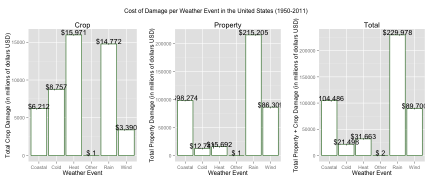

```r
# Gather information determining the relationship between event type and property/crop damage in millions of dollars
economic_by_event_crop <- data.frame(
  event = c("Coastal","Cold","Heat","Other","Rain","Wind"),
  usd_mil = tapply(X = data$total_crop_damage, INDEX = data$EVTYPE, FUN = sum) / 1000000)

economic_by_event_property <- data.frame(
  event = c("Coastal","Cold","Heat","Other","Rain","Wind"),
  usd_mil = tapply(X = data$total_property_damage, INDEX = data$EVTYPE, FUN = sum) / 1000000)

economic_by_event_total <- data.frame(
  event = c("Coastal","Cold","Heat","Other","Rain","Wind"),
  usd_mil = tapply(X = data$total_damage, INDEX = data$EVTYPE, FUN = sum) / 1000000)

# Plot for property/crop/total damage by event type
library(ggplot2)
plot_crop <- ggplot(economic_by_event_crop, aes(x = event, y = usd_mil)) +
  geom_bar(fill = "white", colour = "darkgreen", stat = "identity") +
  labs(x = "Weather Event", y = "Total Crop Damage (in millions of dollars USD)",
    title = "Crop") +
  geom_text(aes(
    label = paste("$", formatC(round(usd_mil, digits = 1), format = "d", big.mark = ",", small.mark = ".", width = 2), sep = ""), ymax = 0),
    size = 5, vjust = 0)
plot_property <- ggplot(economic_by_event_property, aes(x = event, y = usd_mil)) +
  geom_bar(fill = "white", colour = "darkgreen", stat = "identity") +
  labs(x = "Weather Event", y = "Total Property Damage (in millions of dollars USD)",
    title = "Property") +
  geom_text(aes(
    label = paste("$", formatC(round(usd_mil, digits = 1), format = "d", big.mark = ",", small.mark = ".", width = 2), sep = ""), ymax = 0),
    size = 5, vjust = 0)
plot_total <- ggplot(economic_by_event_total, aes(x = event, y = usd_mil)) +
  geom_bar(fill = "white", colour = "darkgreen", stat = "identity") +
  labs(x = "Weather Event", y = "Total Property + Crop Damage (in millions of dollars USD)",
    title = "Total") +
  geom_text(aes(
    label = paste("$", formatC(round(usd_mil, digits = 1), format = "d", big.mark = ",", small.mark = ".", width = 2), sep = ""), ymax = 0),
    size = 5, vjust = 0)
# Make a single plot with all three plots together
library(gridExtra)
print(arrangeGrob(plot_crop ,plot_property, plot_total, ncol=3, main = "\nCost of Damage per Weather Event in the United States (1950-2011)"))
```

**Figure 3**. Monetary damages in millions of dollars USD for a given event type. Property and crop damages are summed from each individual event of a given event type.

## 4. Discussion

**Across the United States, which types of events (as indicated in the EVTYPE variable) are most harmful with respect to population health?**

Comparing the NOAA weather event dataset to U.S. Census population values, we can see that wind type events caused a larger impact to population health by decade when only considering rain and wind events and decades from 1950-1990. With more current U.S. Census data and more detailed pre-1996 NOAA event data, a more thorough analysis could be performed.

**Across the United States, which types of events have the greatest economic consequences?**

From the NOAA weather event dataset, we see that rain-related weather events have caused more total damage than other events for property and property+crop damages from 1950-2011. For total crop damages during that time, heat-related weather events resulted in the most damage. With more detailed pre-1996 NOAA event data, a more thorough analysis could be performed.